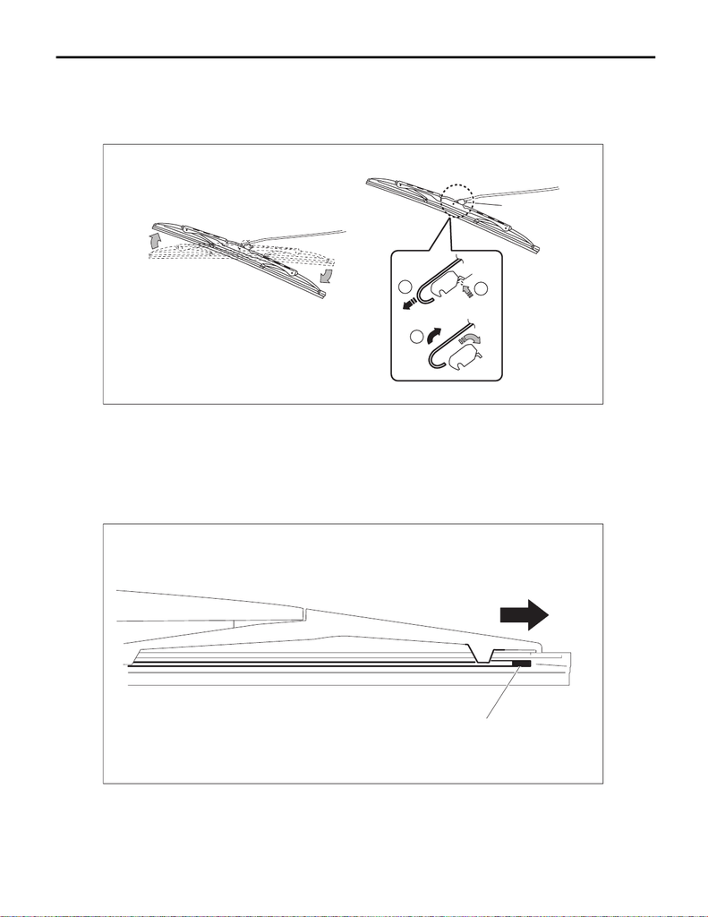

WW-12

Wiper Blade

WIPER AND WASHER SYSTEMS

5. Wiper Blade

A: REMOVAL

While pushing the locking clip (A) up, pull out the blade assembly - windshield wiper in the direction of the ar-

row, and remove it from the arm assembly - windshield wiper.

B: INSTALLATION

Install each part in the reverse order of removal.

CAUTION:

Make sure the locking clip is secured.

C: DISASSEMBLY

Pull side (A) of the wiper rubber stopper and remove the rubber assembly - windshield wiper.

3

2

(A)

(A)

1

WW-00807

WW-00812

(A)

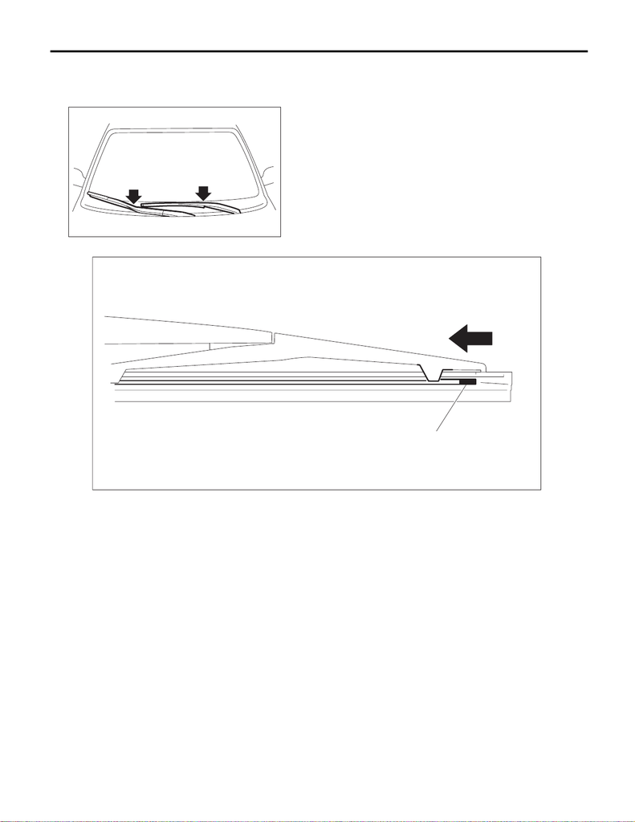

WW-13

Wiper Blade

WIPER AND WASHER SYSTEMS

D: ASSEMBLY

1) Insert the rubber assembly - windshield wiper onto the blade - windshield wiper so that the stopper is in the

position shown in the figure.

2) Make sure the rubber assembly - windshield wiper is securely fastened to the pull stopper (A).

E: INSPECTION

1) When the wiper does not operate properly, inspect the following item.

• Check that the movable part of the blade - windshield wiper moves smoothly.

• Check that the rubber assembly - windshield wiper is not deformed or damaged.

2) Replace with a new part if damage is found.

WW-00749

WW-00813

(A)